# Project: Investigate TMDB Movie Data

- Introduction
- Data Wrangling
- Exploratory Data Analysis
- Conclusions

## Introduction

> **Overview**: In this data set we will be analyzing data collected for TMDB 10,000 movies, this data contains information about movies such as their title, release date, genre, runtime, original budget and the movie revenue. the purpose of this investigation is to find out independant factors that affect movies final revenue and how, factors that will be looked at are such as original budget for the movie, movie run time and genre.

```python
import pandas as pd
import matplotlib.pyplot as plt
import seaborn as sns
%matplotlib inline
pd.set_option('display.max_columns', None)
```

## Data Wrangling

### General Properties

```python
df = pd.read_csv('C:/Users/HP/Desktop/last project/tmdb-movies.csv')
#to show the first few lines of our dataset
df.head()
```

|  | id | imdb_id | popularity | budget | revenue | original_title | cast | homepage | director | tagline | keywords | overview | runtime | genres | production_companies | release_date | vote_count | vote_average | release_year | budget_adj | revenue_adj |
| --- | --- | --- | --- | --- | --- | --- | --- | --- | --- | --- | --- | --- | --- | --- | --- | --- | --- | --- | --- | --- | --- |
| 0 | 135397 | tt0369610 | 32.985763 | 150000000 | 1513528810 | Jurassic World | Chris Pratt\|Bryce Dallas Howard\|Irrfan Khan\|Vi... | http://www.jurassicworld.com/ | Colin Trevorrow | The park is open. | monster\|dna\|tyrannosaurus rex\|velociraptor\|island | Twenty-two years after the events of Jurassic ... | 124 | Action\|Adventure\|Science Fiction\|Thriller | Universal Studios\|Amblin Entertainment\|Legenda... | 6/9/15 | 5562 | 6.5 | 2015 | 1.379999e+08 | 1.392446e+09 |
| 1 | 76341 | tt1392190 | 28.419936 | 150000000 | 378436354 | Mad Max: Fury Road | Tom Hardy\|Charlize Theron\|Hugh Keays-Byrne\|Nic... | http://www.madmaxmovie.com/ | George Miller | What a Lovely Day. | future\|chase\|post-apocalyptic\|dystopia\|australia | An apocalyptic story set in the furthest reach... | 120 | Action\|Adventure\|Science Fiction\|Thriller | Village Roadshow Pictures\|Kennedy Miller Produ... | 5/13/15 | 6185 | 7.1 | 2015 | 1.379999e+08 | 3.481613e+08 |
| 2 | 262500 | tt2908446 | 13.112507 | 110000000 | 295238201 | Insurgent | Shailene Woodley\|Theo James\|Kate Winslet\|Ansel... | http://www.thedivergentseries.movie/#insurgent | Robert Schwentke | One Choice Can Destroy You | based on novel\|revolution\|dystopia\|sequel\|dyst... | Beatrice Prior must confront her inner demons ... | 119 | Adventure\|Science Fiction\|Thriller | Summit Entertainment\|Mandeville Films\|Red Wago... | 3/18/15 | 2480 | 6.3 | 2015 | 1.012000e+08 | 2.716190e+08 |
| 3 | 140607 | tt2488496 | 11.173104 | 200000000 | 2068178225 | Star Wars: The Force Awakens | Harrison Ford\|Mark Hamill\|Carrie Fisher\|Adam D... | http://www.starwars.com/films/star-wars-episod... | J.J. Abrams | Every generation has a story. | android\|spaceship\|jedi\|space opera\|3d | Thirty years after defeating the Galactic Empi... | 136 | Action\|Adventure\|Science Fiction\|Fantasy | Lucasfilm\|Truenorth Productions\|Bad Robot | 12/15/15 | 5292 | 7.5 | 2015 | 1.839999e+08 | 1.902723e+09 |
| 4 | 168259 | tt2820852 | 9.335014 | 190000000 | 1506249360 | Furious 7 | Vin Diesel\|Paul Walker\|Jason Statham\|Michelle ... | http://www.furious7.com/ | James Wan | Vengeance Hits Home | car race\|speed\|revenge\|suspense\|car | Deckard Shaw seeks revenge against Dominic Tor... | 137 | Action\|Crime\|Thriller | Universal Pictures\|Original Film\|Media Rights ... | 4/1/15 | 2947 | 7.3 | 2015 | 1.747999e+08 | 1.385749e+09 |

```python
#getting to know the shape of our dataset(how mnay rows and columns are there?)
df.shape
```

```
(10866, 21)
```

we got here 10866 rows and 21 columns

```python
#before we start digging into the data set we need to look at first at some summery statistics
df.describe()
```

|  | id | popularity | budget | revenue | runtime | vote_count | vote_average | release_year | budget_adj | revenue_adj |
| --- | --- | --- | --- | --- | --- | --- | --- | --- | --- | --- |
| count | 10866.000000 | 10866.000000 | 1.086600e+04 | 1.086600e+04 | 10866.000000 | 10866.000000 | 10866.000000 | 10866.000000 | 1.086600e+04 | 1.086600e+04 |
| mean | 66064.177434 | 0.646441 | 1.462570e+07 | 3.982332e+07 | 102.070863 | 217.389748 | 5.974922 | 2001.322658 | 1.755104e+07 | 5.136436e+07 |
| std | 92130.136561 | 1.000185 | 3.091321e+07 | 1.170035e+08 | 31.381405 | 575.619058 | 0.935142 | 12.812941 | 3.430616e+07 | 1.446325e+08 |
| min | 5.000000 | 0.000065 | 0.000000e+00 | 0.000000e+00 | 0.000000 | 10.000000 | 1.500000 | 1960.000000 | 0.000000e+00 | 0.000000e+00 |
| 25% | 10596.250000 | 0.207583 | 0.000000e+00 | 0.000000e+00 | 90.000000 | 17.000000 | 5.400000 | 1995.000000 | 0.000000e+00 | 0.000000e+00 |
| 50% | 20669.000000 | 0.383856 | 0.000000e+00 | 0.000000e+00 | 99.000000 | 38.000000 | 6.000000 | 2006.000000 | 0.000000e+00 | 0.000000e+00 |
| 75% | 75610.000000 | 0.713817 | 1.500000e+07 | 2.400000e+07 | 111.000000 | 145.750000 | 6.600000 | 2011.000000 | 2.085325e+07 | 3.369710e+07 |
| max | 417859.000000 | 32.985763 | 4.250000e+08 | 2.781506e+09 | 900.000000 | 9767.000000 | 9.200000 | 2015.000000 | 4.250000e+08 | 2.827124e+09 |

from our summery statistics we can see that the average movie revenue is 3.982332e+07, also we can see that there might be some null values in the revenue column as the min is zero the average runtime for a movie is about 102 minutes our data set needs some cleaning as we have alot of null values also some data is found that we won't be using in our analysis that must be dropped.

```python
#then we need to find out how mnay non-null values in each of our columns also to get and idea about our original data types
df.info()
```

```
<class 'pandas.core.frame.DataFrame'>
RangeIndex: 10866 entries, 0 to 10865
Data columns (total 21 columns):
 #   Column                Non-Null Count  Dtype
---  ------                --------------  -----
 0   id                    10866 non-null  int64
 1   imdb_id               10856 non-null  object
 2   popularity            10866 non-null  float64
 3   budget                10866 non-null  int64
 4   revenue               10866 non-null  int64
 5   original_title        10866 non-null  object
 6   cast                  10790 non-null  object
 7   homepage              2936 non-null   object
 8   director              10822 non-null  object
 9   tagline               8042 non-null   object
 10  keywords              9373 non-null   object
 11  overview              10862 non-null  object
 12  runtime               10866 non-null  int64
 13  genres                10843 non-null  object
 14  production_companies  9836 non-null   object
 15  release_date          10866 non-null  object
 16  vote_count            10866 non-null  int64
 17  vote_average          10866 non-null  float64
 18  release_year          10866 non-null  int64
 19  budget_adj            10866 non-null  float64
 20  revenue_adj           10866 non-null  float64
dtypes: float64(4), int64(6), object(11)
memory usage: 1.7+ MB
```

### Data Cleaning

Here we will need to adjust the data set to our investigation, first we will need to delete some columns of data that won't be used such as id, imdb_id, popularity, cast, homepage, director, tagline, keywords, overview, production_companies, release_date, vote_count, vote_average, budget_adj, revenue_adj

then we will need to deal with missing values in our dataset.

```python
rows_to_drop = ['id', 'imdb_id', 'popularity', 'cast','homepage', 'director','tagline', 'keywords', 'overview', 'production_companies', 'release_date', 'vote_count', 'vote_average', 'budget_adj', 'revenue_adj']
df.drop(rows_to_drop, axis = 1, inplace = True)
#this drops the non required columns
df.head(2)
```

|  | budget | revenue | original_title | runtime | genres | release_year |
| --- | --- | --- | --- | --- | --- | --- |
| 0 | 150000000 | 1513528810 | Jurassic World | 124 | Action\|Adventure\|Science Fiction\|Thriller | 2015 |
| 1 | 150000000 | 378436354 | Mad Max: Fury Road | 120 | Action\|Adventure\|Science Fiction\|Thriller | 2015 |

```python
#this to show if we have missing values
df.isnull().count()
```

```
budget            10866
revenue           10866
original_title    10866
runtime           10866
genres            10866
release_year      10866
dtype: int64
```

```python
#get an idea of different columns data types
df.dtypes
```

```
budget             int64
revenue            int64
original_title    object
runtime            int64
genres            object
release_year       int64
dtype: object
```

it shows us that our data is all of consistant type which is integers and text data are all objects After intial look at the dataset, I found that the genres column have multiple genres in one cell separated by | and to be able to deal with each genre we need to separate them

```python
df_genres = df['genres'].str.get_dummies(sep='|')
#this will separate each genre in a separate column with value of 1 or 0
```

```python
df = pd.concat([df, df_genres], axis=1)
#merging the two datasets together
```

```python
df.head()
```

|  | budget | revenue | original_title | runtime | genres | release_year | Action | Adventure | Animation | Comedy | Crime | Documentary | Drama | Family | Fantasy | Foreign | History | Horror | Music | Mystery | Romance | Science Fiction | TV Movie | Thriller | War | Western |
| --- | --- | --- | --- | --- | --- | --- | --- | --- | --- | --- | --- | --- | --- | --- | --- | --- | --- | --- | --- | --- | --- | --- | --- | --- | --- | --- |
| 0 | 150000000 | 1513528810 | Jurassic World | 124 | Action\|Adventure\|Science Fiction\|Thriller | 2015 | 1 | 1 | 0 | 0 | 0 | 0 | 0 | 0 | 0 | 0 | 0 | 0 | 0 | 0 | 0 | 1 | 0 | 1 | 0 | 0 |
| 1 | 150000000 | 378436354 | Mad Max: Fury Road | 120 | Action\|Adventure\|Science Fiction\|Thriller | 2015 | 1 | 1 | 0 | 0 | 0 | 0 | 0 | 0 | 0 | 0 | 0 | 0 | 0 | 0 | 0 | 1 | 0 | 1 | 0 | 0 |
| 2 | 110000000 | 295238201 | Insurgent | 119 | Adventure\|Science Fiction\|Thriller | 2015 | 0 | 1 | 0 | 0 | 0 | 0 | 0 | 0 | 0 | 0 | 0 | 0 | 0 | 0 | 0 | 1 | 0 | 1 | 0 | 0 |
| 3 | 200000000 | 2068178225 | Star Wars: The Force Awakens | 136 | Action\|Adventure\|Science Fiction\|Fantasy | 2015 | 1 | 1 | 0 | 0 | 0 | 0 | 0 | 0 | 1 | 0 | 0 | 0 | 0 | 0 | 0 | 1 | 0 | 0 | 0 | 0 |
| 4 | 190000000 | 1506249360 | Furious 7 | 137 | Action\|Crime\|Thriller | 2015 | 1 | 0 | 0 | 0 | 1 | 0 | 0 | 0 | 0 | 0 | 0 | 0 | 0 | 0 | 0 | 0 | 0 | 1 | 0 | 0 |

```python
df.columns = df.columns.str.lower()
#changing all column names to lower case for easy calling
```

```python
df.rename(columns = {'science fiction':'science_fiction','tv movie':'tv_movie'}, inplace = True)
#renaming column names that has a space inn the middle to have an underscore instead
```

some data were noticed to be zero in budget and revenue columns and according to the quantity of this zero values replacing them with average will affect our results greatly so we will drop them for our analysis to be based on true data

```python
zero_list = df[(df['revenue'] == 0) | (df['budget'] == 0)]
#getting a list of zero values
```

```python
df.drop(zero_list.index,axis = 0, inplace = True)
#dropping all these zero values
```

## Exploratory Data Analysis

### Does movie run time affect its final revenue?)

```python
# movie runtime summery statistics according to our data
df['runtime'].describe()
```

```
count    3855.000000
mean      109.215824
std        19.922166
min        15.000000
25%        95.000000
50%       106.000000
75%       119.000000
max       338.000000
Name: runtime, dtype: float64
```

```python
#this function generates scatter plots by taking arguments
def scatter_plot(x,y,graph_title,x_label,y_label):
    """the function takes the x-axis, Y-axis,title (as a string) ,x-label (as string) & Y-label(as string) as arguments and generate a scatter plot"""
    plt.scatter(x,y)
    plt.title(graph_title)
    plt.xlabel(x_label)
    plt.ylabel(y_label)
    plt.show()
```

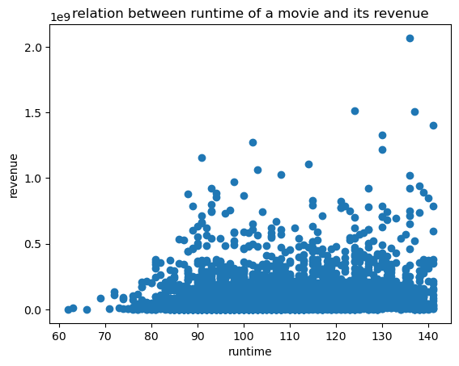

```python
runtime_without_outliers = df[(df['runtime'] > 58) & (df['runtime'] < 142)]
scatter_plot(runtime_without_outliers['runtime'],runtime_without_outliers['revenue'],"relation between runtime of a movie and its revenue","runtime","revenue")
```

as a conclusion from our scatter plot we can see that the movie revenue isn't affected by movie runtime unless movie runtime is below 85 minutes, all movies below 85 minutes didn't acheive as high revenue as movies with higher runtime

### Does movie original budget affect its final evenue?

first thing we must get rid of outliers in our budget data

```python
#this will give us some insights about our budgets
df['budget'].describe()
```

```
count    3.855000e+03
mean     3.720183e+07
std      4.220291e+07
min      1.000000e+00
25%      1.000000e+07
50%      2.400000e+07
75%      5.000000e+07
max      4.250000e+08
Name: budget, dtype: float64
```

I will get rid of all budget values below 1000 USD

```python
low_budget = df[df['budget'] < 1000]
#to get movies with budget lower than 1000 USD then drop them
df.drop(low_budget.index,axis = 0,inplace=True)
```

```python
low_rev = df[df['revenue'] < 1000]
df.drop(low_rev.index,axis = 0,inplace=True)
# that drops movies with revenue lower than 1000 USD
```

now we will plot movies original budget against their final revenue to see the correlation between them

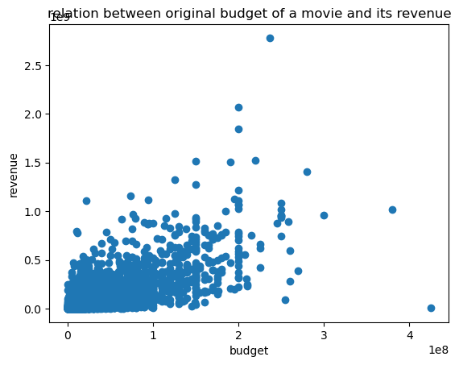

```python
scatter_plot(df['budget'],df['revenue'],"relation between original budget of a movie and its revenue","budget","revenue")
```

from the scatter plot generated we can see the positive correlation between the original movie budget and its revenue So the amount money spent on movie production affect its final revenue positively

### Which movie genres have higher revenue?

first we will explore genres of movies and how they changed over the years

```python
genres_list = ['action', 'adventure', 'animation', 'comedy', 'crime',
       'documentary', 'drama', 'family', 'fantasy', 'foreign', 'history',
       'horror', 'music', 'mystery', 'romance', 'science_fiction', 'tv_movie',
       'thriller', 'war', 'western']
```

```python
genres_over_years = df.groupby('release_year')[genres_list].sum()
#here we got number of movies of each genre for every year
```

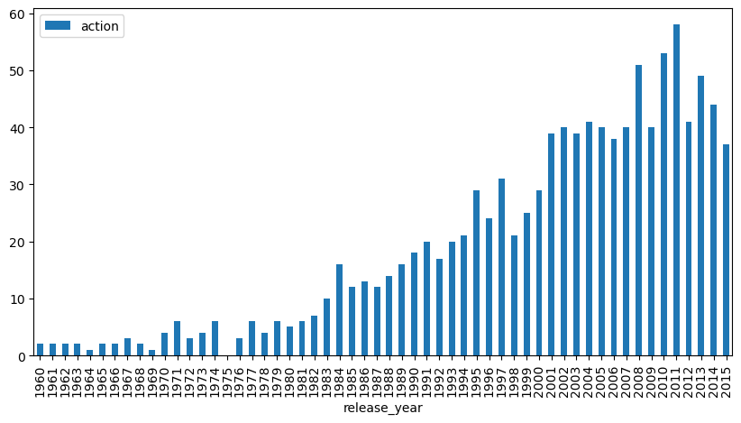

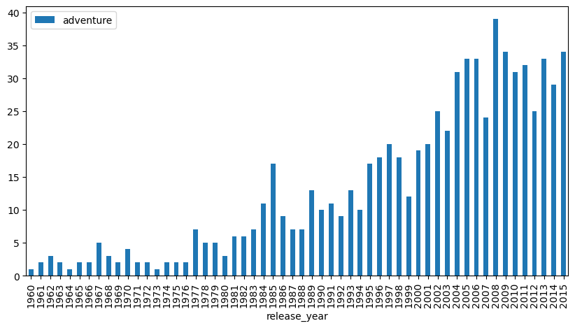

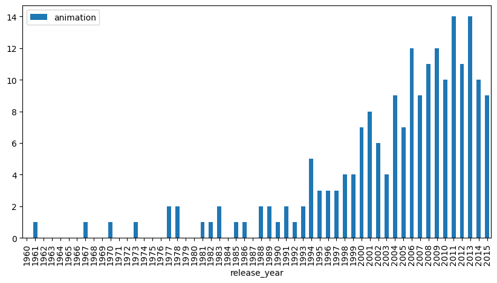

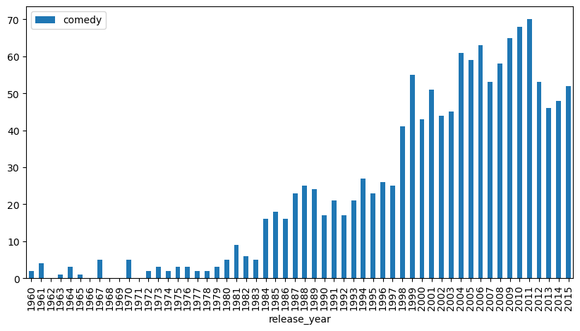

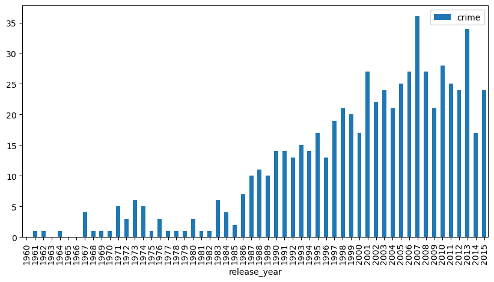

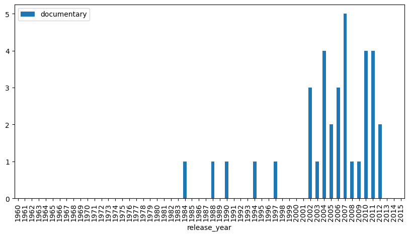

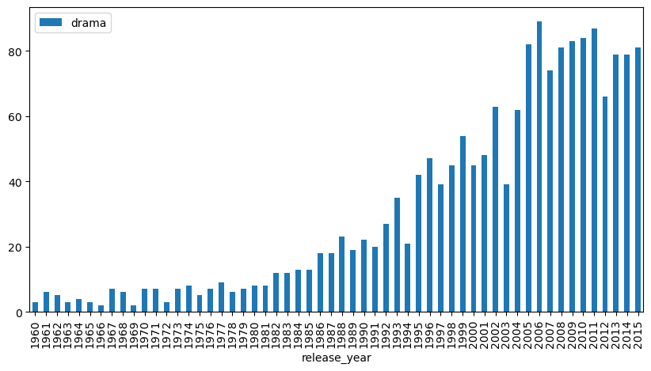

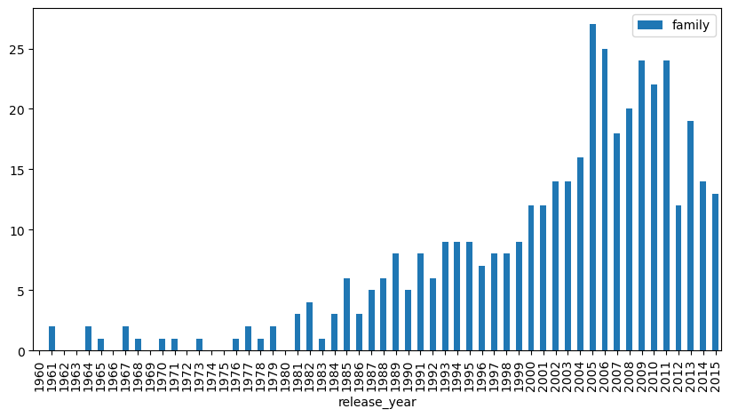

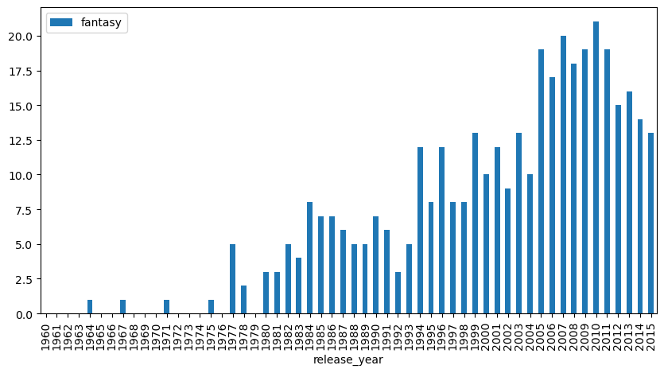

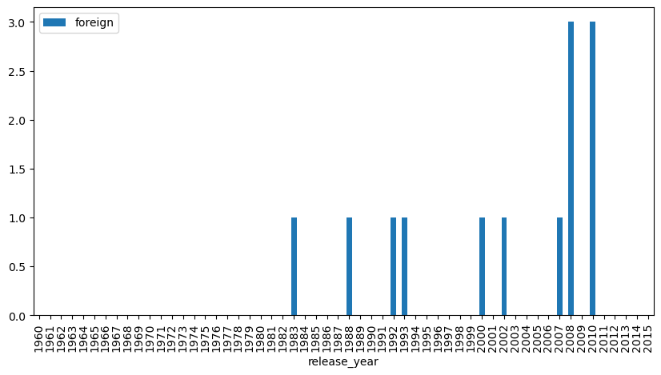

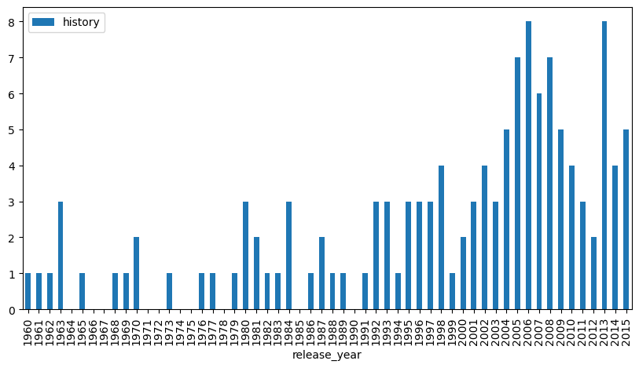

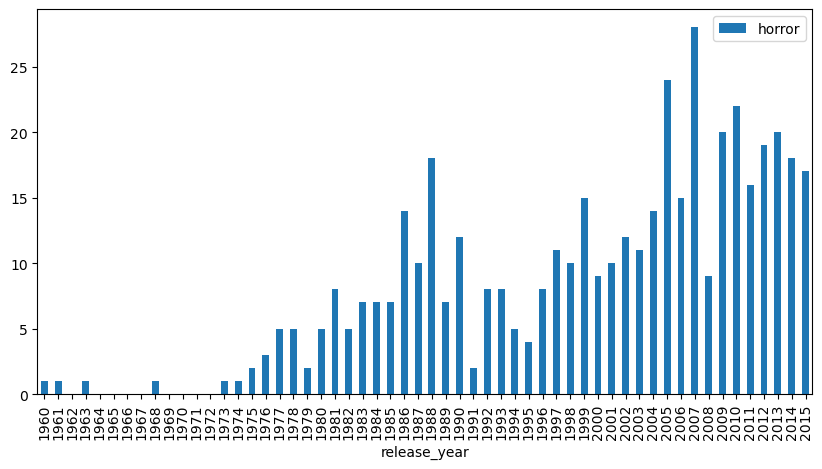

[8 more figures not shown]

```python
for i in genres_list:
    genres_over_years.plot(y = i,kind = 'bar',figsize=(10, 5))
#we get bar plot for every genre over the years
```

```python
#getting a list of mean revenue for each genre
mean_rev_list = []
for i in genres_list:
    mean_revenue = df.groupby(i)['revenue'].mean()[1]
    print('the mean revenue of ' + str(i) +' '+ str(int(mean_revenue)) + ' USD')
    mean_rev_list.append(mean_revenue)
```

```
the mean revenue of action 157634240 USD
the mean revenue of adventure 219899719 USD
the mean revenue of animation 259705634 USD
the mean revenue of comedy 98637204 USD
the mean revenue of crime 84274030 USD
the mean revenue of documentary 22524400 USD
the mean revenue of drama 74725124 USD
the mean revenue of family 205297983 USD
the mean revenue of fantasy 221024851 USD
the mean revenue of foreign 11115957 USD
the mean revenue of history 82041214 USD
the mean revenue of horror 57913216 USD
the mean revenue of music 84532268 USD
the mean revenue of mystery 91311214 USD
the mean revenue of romance 86874148 USD
the mean revenue of science_fiction 164569167 USD
the mean revenue of tv_movie 42000000 USD
the mean revenue of thriller 98471785 USD
the mean revenue of war 106032069 USD
the mean revenue of western 87412920 USD
```

```python
#creating a dictionary for genres and mean revenue
dict_of_genre_revenue={'genres' : genres_list, 'mean_revenue' : mean_rev_list}
```

```python
#transforming our dictionary to a dataframe for easy exploration
genres_revenue = pd.DataFrame(dict_of_genre_revenue)
```

```python
genres_revenue
```

|  | genres | mean_revenue |
| --- | --- | --- |
| 0 | action | 1.576342e+08 |
| 1 | adventure | 2.198997e+08 |
| 2 | animation | 2.597056e+08 |
| 3 | comedy | 9.863720e+07 |
| 4 | crime | 8.427403e+07 |
| 5 | documentary | 2.252440e+07 |
| 6 | drama | 7.472512e+07 |
| 7 | family | 2.052980e+08 |
| 8 | fantasy | 2.210249e+08 |
| 9 | foreign | 1.111596e+07 |
| 10 | history | 8.204121e+07 |
| 11 | horror | 5.791322e+07 |
| 12 | music | 8.453227e+07 |
| 13 | mystery | 9.131121e+07 |
| 14 | romance | 8.687415e+07 |
| 15 | science_fiction | 1.645692e+08 |
| 16 | tv_movie | 4.200000e+07 |
| 17 | thriller | 9.847179e+07 |
| 18 | war | 1.060321e+08 |
| 19 | western | 8.741292e+07 |

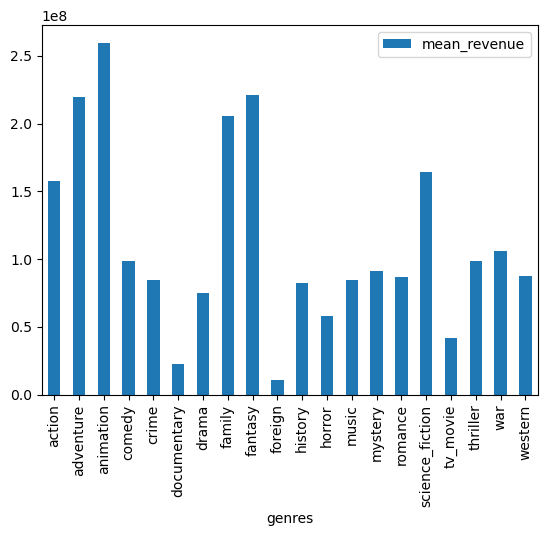

```python
#plotting every genre with its revenue
genres_revenue.plot(x = 'genres',kind = 'bar')
```

from our plot here we can see that animation movies and fantasy movies often have the highest revenue foreign & documentary movies have the lowest revenue